# Lecture 313

2021-11-30

## Data transformations

## Recap

**Prev**: Correlation

- Pearson’s r
- Spearman’s rho
- Kendall’s tau
- Pairs panel
- Chi-square

**Now**: Data transformations

- Z-scores
- Logarithmic transformations
- Inverse hyperbolic sine transformations

## Z-scores

Transform the values as relative to

- the distribution’s mean
- and standard deviation
- the z-score of a value i-th \(x_i\) is calculated as below, where
  - \(\mu\) is the distribution’s mean
  - \(\sigma\) is the distribution’s standard deviation

\[ z_i = \frac{x_i - \mu}{\sigma} \]

Commonly used to render two variables easier to compare

## Example

Distribution of flipper lengths in Palmer’s penguins

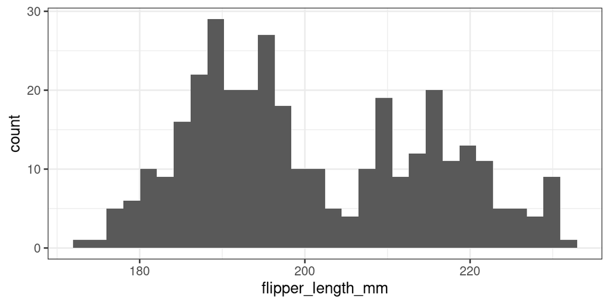

```r
palmerpenguins::penguins %>%
  ggplot2::ggplot(aes(x = flipper_length_mm)) +
  ggplot2::geom_histogram() + ggplot2::theme_bw()
```

## base::scale

Distribution of **zscores** derived from flipper lengths

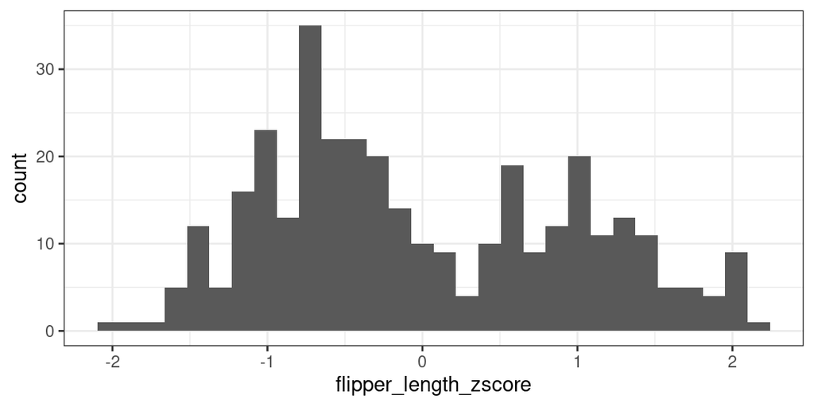

```r
palmerpenguins::penguins %>%
  dplyr::mutate(flipper_length_zscore = scale(flipper_length_mm)) %>%
  ggplot2::ggplot(aes(x = flipper_length_zscore)) +
  ggplot2::geom_histogram() + ggplot2::theme_bw()
```

## base::scale

Distribution of **zscores** derived from body mass

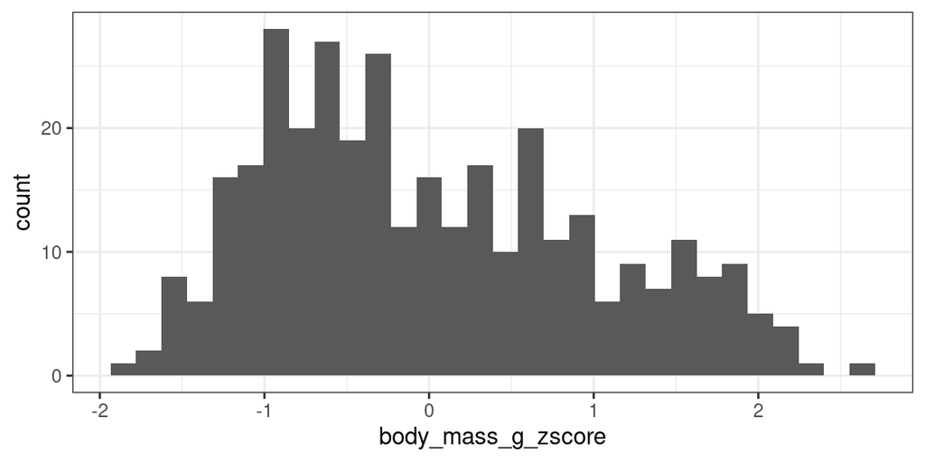

```r
palmerpenguins::penguins %>%
  dplyr::mutate(body_mass_g_zscore = scale(body_mass_g)) %>%
  ggplot2::ggplot(aes(x = body_mass_g_zscore)) +
  ggplot2::geom_histogram() + ggplot2::theme_bw()
```

## Comparison

But, are flipper length and body mass related in penguins (without considering species as separated groups)?

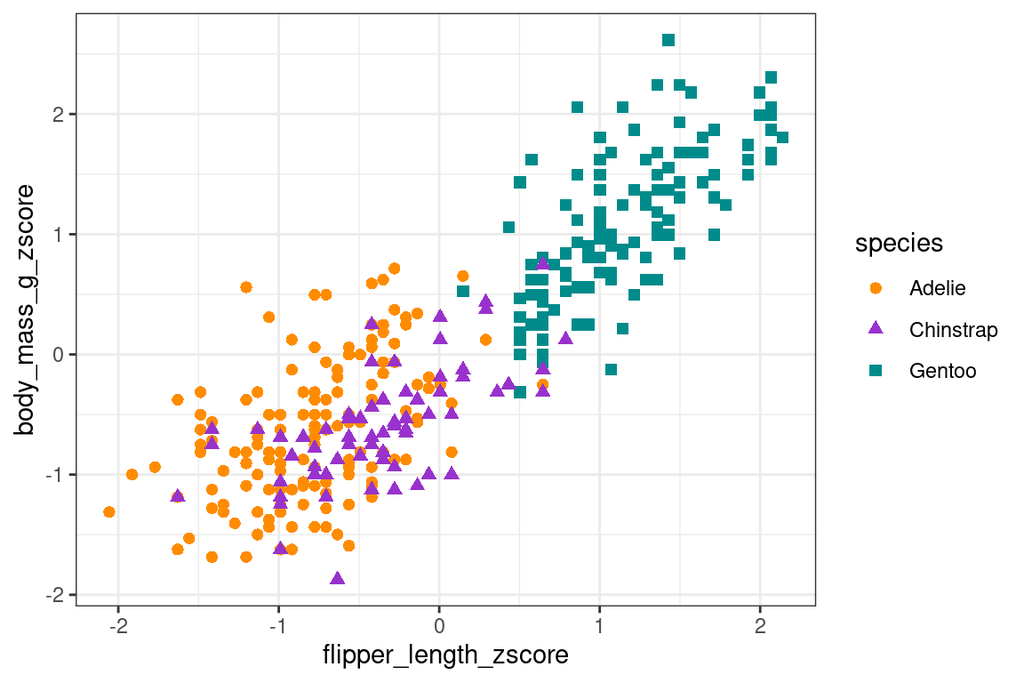

## Log transformation

**Logarithmic** transformations are useful to *“un-skew”* variables

Common approaches include:

- natural logarithm (`log`)
- binary logarithm (`log2`)
- logarithm base 10 (`log10`)

Only possible on values `> 0`

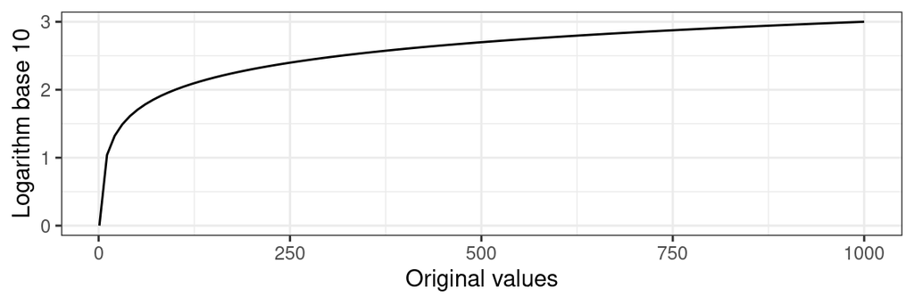

## Example

The number of residents aged 20 to 24 (`u011`) in the areas of Leicester described as *“Cosmopolitans”* by the [2011 Output Area Classification](https://www.gov.uk/government/statistics/2011-area-classification-for-super-output-areas) is skewed

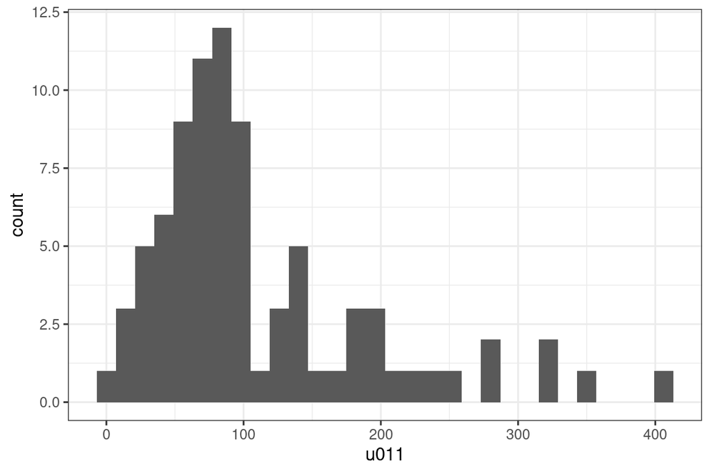

|  | u011 |
| --- | --- |
| skewness | 1.521 |
| skew.2SE | 2.879 |
| kurtosis | 2.089 |
| kurt.2SE | 1.999 |
| normtest.W | 0.847 |
| normtest.p | 0.000 |

## Example

However, it’s logarithm base 10 is normally distributed, thus it can be used with tests requiring normally distributed values

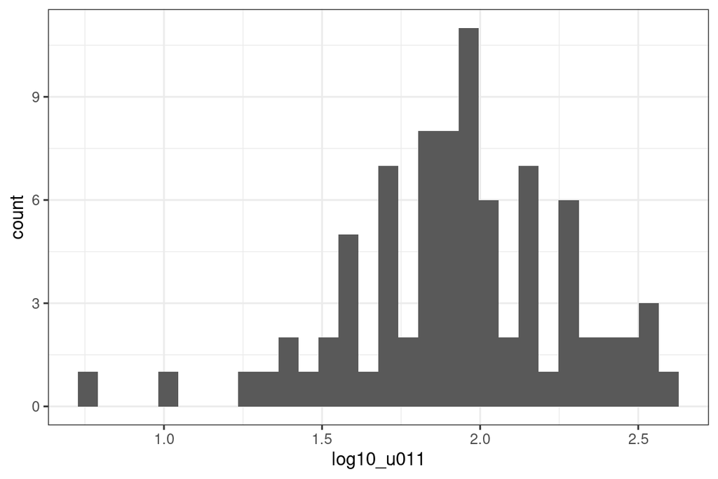

|  | log10_u011 |
| --- | --- |
| skewness | -0.504 |
| skew.2SE | -0.953 |
| kurtosis | 0.872 |
| kurt.2SE | 0.834 |
| normtest.W | 0.976 |
| normtest.p | 0.118 |

```r
mutate(log10_u011 = log10(u011))
```

## Inverse hyperbolic sine

**Inverse hyperbolic sine** transformations are useful to *“un-skew”* variables

- similar to logarithmic transformations
- defined on all values
- in R: `asinh`

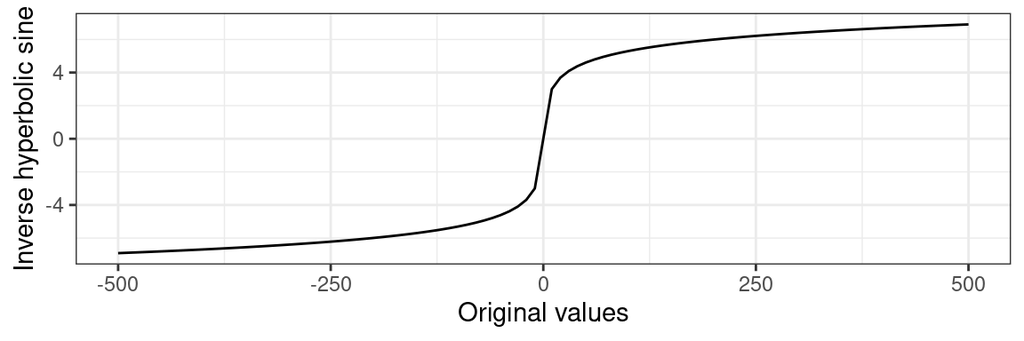

## Example

The Inverse hyperbolic sine is also normally distributed

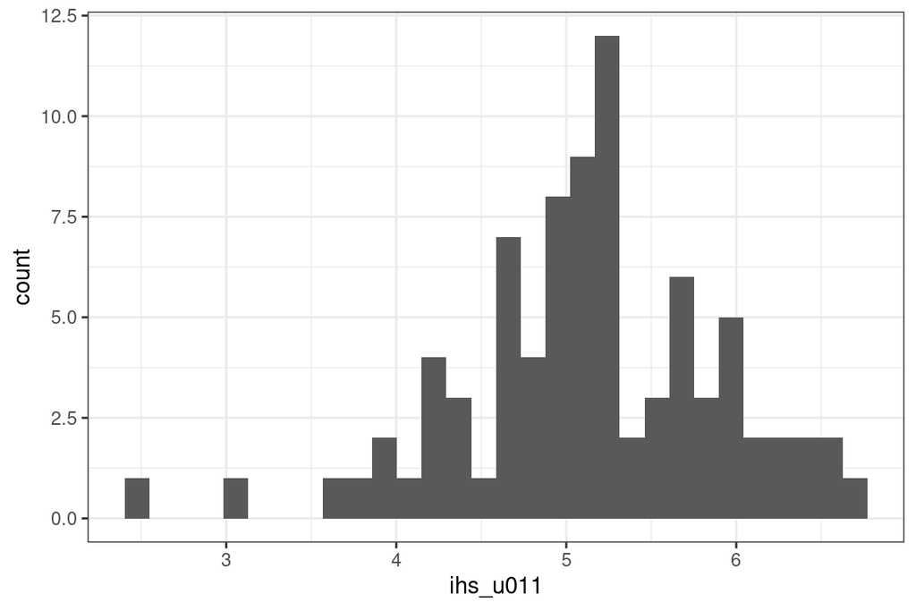

[output not shown]

```r
mutate(ihs_u011 = asinh(u011))
```

## Example

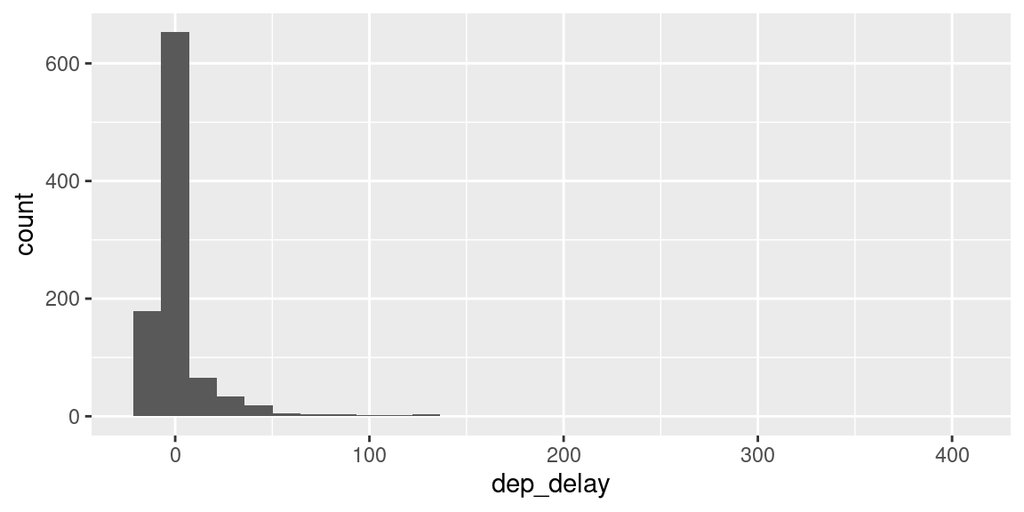

## Example

*Inverse hyperbolic sine* can still be applied. Here it partially unskews the distribution

```r
mutate(
  dep_delay_ihs =
    asinh(dep_delay)
)
```

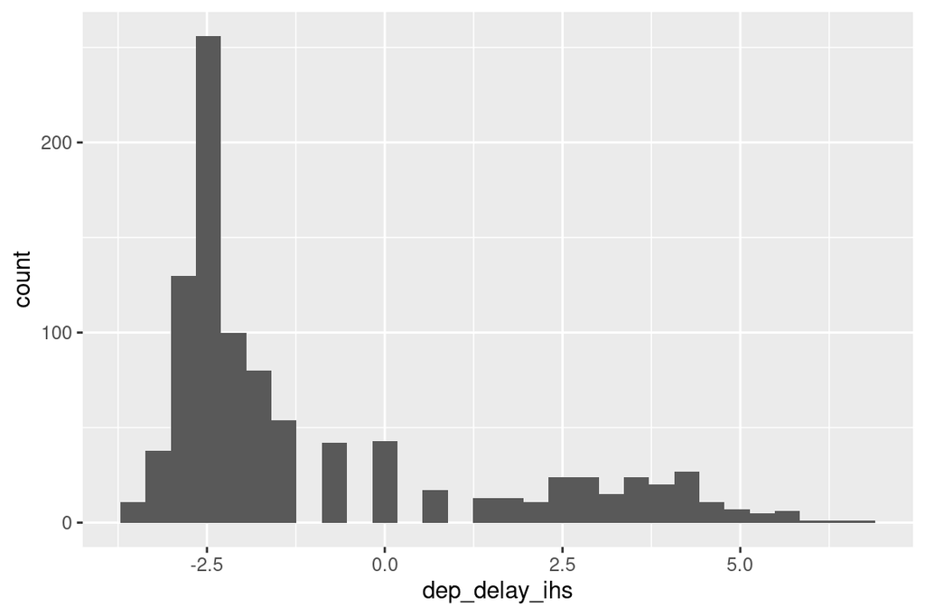

|  | dep_delay_ihs |
| --- | --- |
| skewness | 1.273 |
| skew.2SE | 8.122 |
| kurtosis | 0.242 |
| kurt.2SE | 0.773 |
| normtest.W | 0.778 |
| normtest.p | 0.000 |

## Summary

Data transformations

- Z-scores
- Logarithmic transformations
- Inverse hyperbolic sine transformations

**Next**: Practical session

- Comparing means
- Correlation